# Exploratory Analysis

Tianyou Wang

2022-10-11

## *Setting Opotions*

From last lecture, in addition to figure sizing, we include a few other figure preferences in global options declared at the outset of each .Rmd file (this code chunk just gets copy-and-pasted to the beginning of every new file).

## Load the Weather Data

`lubridate::floor_date(date, unit = "month")` round the days to the first day of the month.

```r
weather_df =
  rnoaa::meteo_pull_monitors(
    c("USW00094728", "USC00519397", "USS0023B17S"),
    var = c("PRCP", "TMIN", "TMAX"),
    date_min = "2017-01-01",
    date_max = "2017-12-31") %>%
  mutate(
    name = recode(
      id,
      USW00094728 = "CentralPark_NY",
      USC00519397 = "Waikiki_HA",
      USS0023B17S = "Waterhole_WA"),
    tmin = tmin / 10,
    tmax = tmax / 10,
    month = lubridate::floor_date(date, unit = "month")) %>%
  select(name, id, everything())
```

```
## using cached file: ~/Library/Caches/R/noaa_ghcnd/USW00094728.dly
```

```
## date created (size, mb): 2022-09-03 15:53:33 (8.394)
```

```
## file min/max dates: 1869-01-01 / 2022-09-30
```

```
## using cached file: ~/Library/Caches/R/noaa_ghcnd/USC00519397.dly
```

```
## date created (size, mb): 2022-09-03 15:53:37 (1.697)
```

```
## file min/max dates: 1965-01-01 / 2020-02-29
```

```
## using cached file: ~/Library/Caches/R/noaa_ghcnd/USS0023B17S.dly
```

```
## date created (size, mb): 2022-09-03 15:53:39 (0.949)
```

```
## file min/max dates: 1999-09-01 / 2022-09-30
```

```r
weather_df
```

```
## # A tibble: 1,095 × 7
##    name           id          date        prcp  tmax  tmin month
##    <chr>          <chr>       <date>     <dbl> <dbl> <dbl> <date>
##  1 CentralPark_NY USW00094728 2017-01-01     0   8.9   4.4 2017-01-01
##  2 CentralPark_NY USW00094728 2017-01-02    53   5     2.8 2017-01-01
##  3 CentralPark_NY USW00094728 2017-01-03   147   6.1   3.9 2017-01-01
##  4 CentralPark_NY USW00094728 2017-01-04     0  11.1   1.1 2017-01-01
##  5 CentralPark_NY USW00094728 2017-01-05     0   1.1  -2.7 2017-01-01
##  6 CentralPark_NY USW00094728 2017-01-06    13   0.6  -3.8 2017-01-01
##  7 CentralPark_NY USW00094728 2017-01-07    81  -3.2  -6.6 2017-01-01
##  8 CentralPark_NY USW00094728 2017-01-08     0  -3.8  -8.8 2017-01-01
##  9 CentralPark_NY USW00094728 2017-01-09     0  -4.9  -9.9 2017-01-01
## 10 CentralPark_NY USW00094728 2017-01-10     0   7.8  -6   2017-01-01
## # … with 1,085 more rows
```

## *`group_by`*

Datasets are often comprised of groups defined by one or more (categorical) variable; group_by() makes these groupings explicit so that they can be included in subsequent operations. For example, we might group weather_df by name, which give us 3 groups.

```r
weather_df %>%
  group_by(name)
```

```
## # A tibble: 1,095 × 7
## # Groups:   name [3]
##    name           id          date        prcp  tmax  tmin month
##    <chr>          <chr>       <date>     <dbl> <dbl> <dbl> <date>
##  1 CentralPark_NY USW00094728 2017-01-01     0   8.9   4.4 2017-01-01
##  2 CentralPark_NY USW00094728 2017-01-02    53   5     2.8 2017-01-01
##  3 CentralPark_NY USW00094728 2017-01-03   147   6.1   3.9 2017-01-01
##  4 CentralPark_NY USW00094728 2017-01-04     0  11.1   1.1 2017-01-01
##  5 CentralPark_NY USW00094728 2017-01-05     0   1.1  -2.7 2017-01-01
##  6 CentralPark_NY USW00094728 2017-01-06    13   0.6  -3.8 2017-01-01
##  7 CentralPark_NY USW00094728 2017-01-07    81  -3.2  -6.6 2017-01-01
##  8 CentralPark_NY USW00094728 2017-01-08     0  -3.8  -8.8 2017-01-01
##  9 CentralPark_NY USW00094728 2017-01-09     0  -4.9  -9.9 2017-01-01
## 10 CentralPark_NY USW00094728 2017-01-10     0   7.8  -6   2017-01-01
## # … with 1,085 more rows
```

For example, we might group weather_df by name and month, which give us 36 groups.

```r
weather_df %>%
  group_by(name, month)
```

```
## # A tibble: 1,095 × 7
## # Groups:   name, month [36]
##    name           id          date        prcp  tmax  tmin month
##    <chr>          <chr>       <date>     <dbl> <dbl> <dbl> <date>
##  1 CentralPark_NY USW00094728 2017-01-01     0   8.9   4.4 2017-01-01
##  2 CentralPark_NY USW00094728 2017-01-02    53   5     2.8 2017-01-01
##  3 CentralPark_NY USW00094728 2017-01-03   147   6.1   3.9 2017-01-01
##  4 CentralPark_NY USW00094728 2017-01-04     0  11.1   1.1 2017-01-01
##  5 CentralPark_NY USW00094728 2017-01-05     0   1.1  -2.7 2017-01-01
##  6 CentralPark_NY USW00094728 2017-01-06    13   0.6  -3.8 2017-01-01
##  7 CentralPark_NY USW00094728 2017-01-07    81  -3.2  -6.6 2017-01-01
##  8 CentralPark_NY USW00094728 2017-01-08     0  -3.8  -8.8 2017-01-01
##  9 CentralPark_NY USW00094728 2017-01-09     0  -4.9  -9.9 2017-01-01
## 10 CentralPark_NY USW00094728 2017-01-10     0   7.8  -6   2017-01-01
## # … with 1,085 more rows
```

We can also ungroup after we group.

```r
weather_df %>%
  group_by(name, month) %>%
  ungroup(month)
```

```
## # A tibble: 1,095 × 7
## # Groups:   name [3]
##    name           id          date        prcp  tmax  tmin month
##    <chr>          <chr>       <date>     <dbl> <dbl> <dbl> <date>
##  1 CentralPark_NY USW00094728 2017-01-01     0   8.9   4.4 2017-01-01
##  2 CentralPark_NY USW00094728 2017-01-02    53   5     2.8 2017-01-01
##  3 CentralPark_NY USW00094728 2017-01-03   147   6.1   3.9 2017-01-01
##  4 CentralPark_NY USW00094728 2017-01-04     0  11.1   1.1 2017-01-01
##  5 CentralPark_NY USW00094728 2017-01-05     0   1.1  -2.7 2017-01-01
##  6 CentralPark_NY USW00094728 2017-01-06    13   0.6  -3.8 2017-01-01
##  7 CentralPark_NY USW00094728 2017-01-07    81  -3.2  -6.6 2017-01-01
##  8 CentralPark_NY USW00094728 2017-01-08     0  -3.8  -8.8 2017-01-01
##  9 CentralPark_NY USW00094728 2017-01-09     0  -4.9  -9.9 2017-01-01
## 10 CentralPark_NY USW00094728 2017-01-10     0   7.8  -6   2017-01-01
## # … with 1,085 more rows
```

## *Counting Things*

### `summarize()`

We will frequently use `summarize()` to create one-number-variable that summaries within each group, or use `mutate()` to define variables within groups.

For example, counting the number of observations in each month.

```r
weather_df %>%
  group_by(month) %>%
  summarize(n_obs = n())
```

```
## # A tibble: 12 × 2
##    month      n_obs
##    <date>     <int>
##  1 2017-01-01    93
##  2 2017-02-01    84
##  3 2017-03-01    93
##  4 2017-04-01    90
##  5 2017-05-01    93
##  6 2017-06-01    90
##  7 2017-07-01    93
##  8 2017-08-01    93
##  9 2017-09-01    90
## 10 2017-10-01    93
## 11 2017-11-01    90
## 12 2017-12-01    93
```

*** `count()` We can also use `count()` in place of `group_by()` and `summarize()`.

```r
weather_df %>%
  count(name, month, name = "n_obs")
```

```
## # A tibble: 36 × 3
##    name           month      n_obs
##    <chr>          <date>     <int>
##  1 CentralPark_NY 2017-01-01    31
##  2 CentralPark_NY 2017-02-01    28
##  3 CentralPark_NY 2017-03-01    31
##  4 CentralPark_NY 2017-04-01    30
##  5 CentralPark_NY 2017-05-01    31
##  6 CentralPark_NY 2017-06-01    30
##  7 CentralPark_NY 2017-07-01    31
##  8 CentralPark_NY 2017-08-01    31
##  9 CentralPark_NY 2017-09-01    30
## 10 CentralPark_NY 2017-10-01    31
## # … with 26 more rows
```

**Never** use base R’s `table()` function!!! `count()` is a useful tidyverse alternative to Base R’s `table()` function. Both functions produce summaries of how often values appear (number of occurrences), but table’s output is a classic n*2 table and is hard to do any additional work with it. `count()` adds one or more numeric columns to the original data frame, which can be used or manipulated later directly. For an example, run the code below and check the classic 12-by-2 table.

```r
weather_df %>%
  pull(month) %>%
  table()
```

```
## .
## 2017-01-01 2017-02-01 2017-03-01 2017-04-01 2017-05-01 2017-06-01 2017-07-01
##         93         84         93         90         93         90         93
## 2017-08-01 2017-09-01 2017-10-01 2017-11-01 2017-12-01
##         93         90         93         90         93
```

### Other helpful counters

We can use `summarize()` to compute *multiple summaries* within each group. As an example, we count the number of observations in each month and the number of distinct dates in each month.

```r
weather_df %>%
  group_by(month) %>%
  summarize(
    n_obs = n(),
    n_days = n_distinct(date))
```

```
## # A tibble: 12 × 3
##    month      n_obs n_days
##    <date>     <int>  <int>
##  1 2017-01-01    93     31
##  2 2017-02-01    84     28
##  3 2017-03-01    93     31
##  4 2017-04-01    90     30
##  5 2017-05-01    93     31
##  6 2017-06-01    90     30
##  7 2017-07-01    93     31
##  8 2017-08-01    93     31
##  9 2017-09-01    90     30
## 10 2017-10-01    93     31
## 11 2017-11-01    90     30
## 12 2017-12-01    93     31
```

## A digression on 2-by-2 tablee

Let’s say we want to look at the number of cold and not-cold days in Central Park and Waterhole. We can do this with some extra data manipulation steps through `group_by` and `summarize`. Note:

- `!=` means not equal to..
- `TRUE ~ ""` if there is thing don’t fill in any group, just assign “”

```r
weather_df %>%
  filter(name != "Waikiki_HA") %>%
  mutate(
    cold = case_when(
      tmax <  5 ~ "cold",
      tmax >= 5 ~ "not_cold",
      TRUE      ~ ""
  )) %>%
  group_by(name, cold) %>%
  summarize(count = n())
```

```
## # A tibble: 4 × 3
## # Groups:   name [2]
##   name           cold     count
##   <chr>          <chr>    <int>
## 1 CentralPark_NY cold        44
## 2 CentralPark_NY not_cold   321
## 3 Waterhole_WA   cold       172
## 4 Waterhole_WA   not_cold   193
```

We get a “tidy” table in the previous example, and that’s also a data frame. We could re-organize it into a more standard (non-tidy) 2x2 table using `pivot_wider`, or you could use `janitor::tabyl(1-, 2-, or 3-way )`.

```r
weather_df %>%
  filter(name != "Waikiki_HA") %>%
  mutate(
    cold = case_when(
      tmax <  5 ~ "cold",
      tmax >= 5 ~ "not_cold",
      TRUE      ~ ""
  )) %>%
  janitor::tabyl(name, cold)
```

```
##            name cold not_cold
##  CentralPark_NY   44      321
##    Waterhole_WA  172      193
```

## *General Summaries*

Standard statistical summaries are regularly computed in `summarize()` using functions like `mean()`, `median()`, `var()`, `sd()`, `mad()`, `IQR()`, `min()`, and `max()`. To use these, you put the variable to which they apply in the function. We can also include any additional arguments as necessary, such as `na.rm = TRUE` which get ride off the missing value.

```r
weather_df %>%
  group_by(month) %>%
  summarize(
    mean_tmax = mean(tmax, na.rm = TRUE),
    mean_prec = mean(prcp, na.rm = TRUE),
    median_tmax = median(tmax, na.rm = TRUE),
    sd_tmax = sd(tmax, na.rm = TRUE))
```

```
## # A tibble: 12 × 5
##    month      mean_tmax mean_prec median_tmax sd_tmax
##    <date>         <dbl>     <dbl>       <dbl>   <dbl>
##  1 2017-01-01      10.8     37.0          6.1   13.1
##  2 2017-02-01      12.2     57.9          8.3   12.1
##  3 2017-03-01      13.0     54.6          8.3   12.4
##  4 2017-04-01      17.3     32.9         18.3   11.2
##  5 2017-05-01      19.9     28.4         19.4    9.29
##  6 2017-06-01      23.5     18.7         27.2    8.73
##  7 2017-07-01      25.5     12.7         29.4    7.15
##  8 2017-08-01      26.3     10.2         27.2    5.87
##  9 2017-09-01      23.8      9.94        26.1    8.42
## 10 2017-10-01      20.1     41.5         22.2    9.75
## 11 2017-11-01      14.0     61.5         12.0   11.6
## 12 2017-12-01      11.0     40.2          8.9   11.9
```

If you want to summarize multiple columns using the same summary, the `across()` function is helpful. Under this example, R calculate mean for variable tmin to prcp.

```r
weather_df %>%
  group_by(name, month) %>%
  summarize(across(tmin:prcp, mean))
```

```
## # A tibble: 36 × 5
## # Groups:   name [3]
##    name           month        tmin  tmax  prcp
##    <chr>          <date>      <dbl> <dbl> <dbl>
##  1 CentralPark_NY 2017-01-01  0.748  5.98  39.5
##  2 CentralPark_NY 2017-02-01  1.45   9.28  22.5
##  3 CentralPark_NY 2017-03-01 -0.177  8.22  43.0
##  4 CentralPark_NY 2017-04-01  9.66  18.3   32.5
##  5 CentralPark_NY 2017-05-01 12.2   20.1   52.3
##  6 CentralPark_NY 2017-06-01 18.2   26.3   40.4
##  7 CentralPark_NY 2017-07-01 21.0   28.7   34.3
##  8 CentralPark_NY 2017-08-01 19.5   27.2   27.4
##  9 CentralPark_NY 2017-09-01 17.4   25.4   17.0
## 10 CentralPark_NY 2017-10-01 13.9   21.8   34.3
## # … with 26 more rows
```

The fact that `summarize()` produces a data frame is important. We can incorporate grouping and summarizing within broader analysis pipelines. For example, we can create a plot based on the monthly summary:

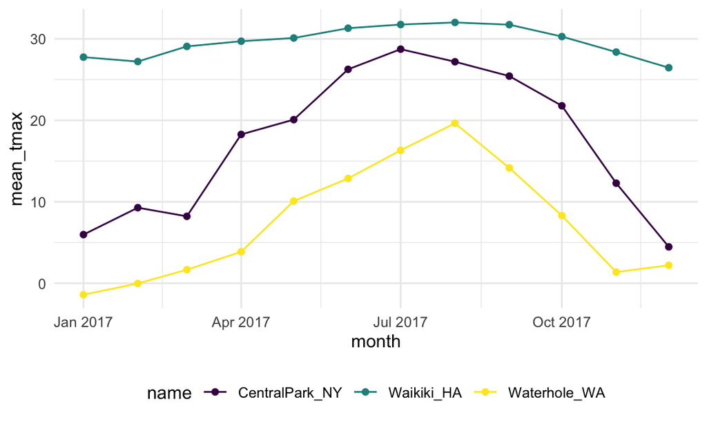

```r
weather_df %>%
  group_by(name, month) %>%
  summarize(mean_tmax = mean(tmax, na.rm = TRUE),
            mean_prec = mean(prcp, na.rm = TRUE),
            median_tmax = median(tmax, na.rm = TRUE)
            ) %>%
  ggplot(aes(x = month, y = mean_tmax, color = name)) +
  geom_point() +
  geom_line() +
  theme(legend.position = "bottom")
```

Reminder: sometimes your results are easier to read in another format. Note: `knitr::kable` is a table generator, which create tables in R_Markdown, Html, LaTex….. We can also add design decisions, such as `digits = 1` which saves numbers in 1 decimal place.

```r
weather_df %>%
  group_by(name, month) %>%
  summarize(mean_tmax = mean(tmax)) %>%
  pivot_wider(
    names_from = name,
    values_from = mean_tmax) %>%
  knitr::kable(digits = 1)
```

| month | CentralPark_NY | Waikiki_HA | Waterhole_WA |
| --- | --- | --- | --- |
| 2017-01-01 | 6.0 | 27.8 | -1.4 |
| 2017-02-01 | 9.3 | 27.2 | 0.0 |
| 2017-03-01 | 8.2 | 29.1 | 1.7 |
| 2017-04-01 | 18.3 | 29.7 | 3.9 |
| 2017-05-01 | 20.1 | NA | 10.1 |
| 2017-06-01 | 26.3 | 31.3 | 12.9 |
| 2017-07-01 | 28.7 | NA | 16.3 |
| 2017-08-01 | 27.2 | 32.0 | 19.6 |
| 2017-09-01 | 25.4 | 31.7 | 14.2 |
| 2017-10-01 | 21.8 | 30.3 | 8.3 |
| 2017-11-01 | 12.3 | 28.4 | 1.4 |
| 2017-12-01 | 4.5 | 26.5 | 2.2 |

## `group_by` and `mutate`

`summarize()` collapses groups into single data points. In contrast, using `mutate()` in conjuntion with `group_by()` will retain all original data points and add new variables computed within groups.

Suppose we want to compare the daily max temperature to the annual average max temperature for each station separately, and plot the result.

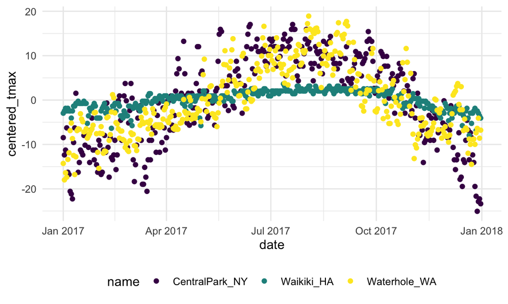

```r
weather_df %>%
  group_by(name) %>%
  mutate(
    mean_tmax = mean(tmax, na.rm = TRUE),
    centered_tmax = tmax - mean_tmax) %>%
  ggplot(aes(x = date, y = centered_tmax, color = name)) +
    geom_point()
```

## *Window functions*

The previous example used `mean()` to compute the mean within each group. `mean()` takes n inputs and produces a single output. Window functions, in contrast, take n inputs and return n outputs, and the outputs depend on all the inputs.

### ranking

Note: `temp_ranking = min_rank(tmax)` ranks the tmax from low to high, it also assign numbers(ranks) in the “temp_ranking” variable. If we want the opposite order, we can use `temp_ranking = min_rank(desc(tmax)`.

```r
weather_df %>%
  group_by(name, month) %>%
  mutate(temp_ranking = min_rank(tmax))
```

```
## # A tibble: 1,095 × 8
## # Groups:   name, month [36]
##    name           id          date        prcp  tmax  tmin month      temp_ran…¹
##    <chr>          <chr>       <date>     <dbl> <dbl> <dbl> <date>          <int>
##  1 CentralPark_NY USW00094728 2017-01-01     0   8.9   4.4 2017-01-01         22
##  2 CentralPark_NY USW00094728 2017-01-02    53   5     2.8 2017-01-01         12
##  3 CentralPark_NY USW00094728 2017-01-03   147   6.1   3.9 2017-01-01         15
##  4 CentralPark_NY USW00094728 2017-01-04     0  11.1   1.1 2017-01-01         27
##  5 CentralPark_NY USW00094728 2017-01-05     0   1.1  -2.7 2017-01-01          5
##  6 CentralPark_NY USW00094728 2017-01-06    13   0.6  -3.8 2017-01-01          4
##  7 CentralPark_NY USW00094728 2017-01-07    81  -3.2  -6.6 2017-01-01          3
##  8 CentralPark_NY USW00094728 2017-01-08     0  -3.8  -8.8 2017-01-01          2
##  9 CentralPark_NY USW00094728 2017-01-09     0  -4.9  -9.9 2017-01-01          1
## 10 CentralPark_NY USW00094728 2017-01-10     0   7.8  -6   2017-01-01         21
## # … with 1,085 more rows, and abbreviated variable name ¹temp_ranking
```

This sort of ranking is useful because we can filter data based on rank. We could, for example, keep only the day with the lowest max temperature within each month:

```r
weather_df %>%
  group_by(name, month) %>%
  mutate(temp_ranking = min_rank(tmax)) %>%
  filter(min_rank(tmax) == 1)
```

```
## # A tibble: 42 × 8
## # Groups:   name, month [36]
##    name           id          date        prcp  tmax  tmin month      temp_ran…¹
##    <chr>          <chr>       <date>     <dbl> <dbl> <dbl> <date>          <int>
##  1 CentralPark_NY USW00094728 2017-01-09     0  -4.9  -9.9 2017-01-01          1
##  2 CentralPark_NY USW00094728 2017-02-10     0   0    -7.1 2017-02-01          1
##  3 CentralPark_NY USW00094728 2017-03-15     0  -3.2  -6.6 2017-03-01          1
##  4 CentralPark_NY USW00094728 2017-04-01     0   8.9   2.8 2017-04-01          1
##  5 CentralPark_NY USW00094728 2017-05-13   409  11.7   7.2 2017-05-01          1
##  6 CentralPark_NY USW00094728 2017-06-06    15  14.4  11.1 2017-06-01          1
##  7 CentralPark_NY USW00094728 2017-07-25     0  21.7  16.7 2017-07-01          1
##  8 CentralPark_NY USW00094728 2017-08-29    74  20    16.1 2017-08-01          1
##  9 CentralPark_NY USW00094728 2017-09-30     0  18.9  12.2 2017-09-01          1
## 10 CentralPark_NY USW00094728 2017-10-31     0  13.9   7.2 2017-10-01          1
## # … with 32 more rows, and abbreviated variable name ¹temp_ranking
```

Note: We can skip the `mutate()` statement that create a ranking variable, and gone straight to filtering based on the result. For example, we could also keep the three days with the highest max temperature:

```r
weather_df %>%
  group_by(name, month) %>%
  filter(min_rank(desc(tmax)) < 4)
```

```
## # A tibble: 149 × 7
## # Groups:   name, month [36]
##    name           id          date        prcp  tmax  tmin month
##    <chr>          <chr>       <date>     <dbl> <dbl> <dbl> <date>
##  1 CentralPark_NY USW00094728 2017-01-12    13  18.9   8.3 2017-01-01
##  2 CentralPark_NY USW00094728 2017-01-13     0  16.7   0   2017-01-01
##  3 CentralPark_NY USW00094728 2017-01-26     5  13.3   6.1 2017-01-01
##  4 CentralPark_NY USW00094728 2017-02-19     0  18.3  11.7 2017-02-01
##  5 CentralPark_NY USW00094728 2017-02-23     0  18.3   6.7 2017-02-01
##  6 CentralPark_NY USW00094728 2017-02-24     0  21.1  14.4 2017-02-01
##  7 CentralPark_NY USW00094728 2017-03-01    30  21.1  12.2 2017-03-01
##  8 CentralPark_NY USW00094728 2017-03-02     0  17.8   1.7 2017-03-01
##  9 CentralPark_NY USW00094728 2017-03-25     3  16.7   5.6 2017-03-01
## 10 CentralPark_NY USW00094728 2017-04-16     0  30.6  15   2017-04-01
## # … with 139 more rows
```

### lag

Lags are used to compare an observation to it’s previous value. This is useful, for example, to find the day-by-day change in tmax within each station over the year.

```r
weather_df %>%
  group_by(name) %>%
  mutate(temp_change = tmax - lag(tmax))
```

```
## # A tibble: 1,095 × 8
## # Groups:   name [3]
##    name           id          date        prcp  tmax  tmin month      temp_cha…¹
##    <chr>          <chr>       <date>     <dbl> <dbl> <dbl> <date>          <dbl>
##  1 CentralPark_NY USW00094728 2017-01-01     0   8.9   4.4 2017-01-01     NA
##  2 CentralPark_NY USW00094728 2017-01-02    53   5     2.8 2017-01-01     -3.9
##  3 CentralPark_NY USW00094728 2017-01-03   147   6.1   3.9 2017-01-01      1.1
##  4 CentralPark_NY USW00094728 2017-01-04     0  11.1   1.1 2017-01-01      5
##  5 CentralPark_NY USW00094728 2017-01-05     0   1.1  -2.7 2017-01-01    -10
##  6 CentralPark_NY USW00094728 2017-01-06    13   0.6  -3.8 2017-01-01     -0.5
##  7 CentralPark_NY USW00094728 2017-01-07    81  -3.2  -6.6 2017-01-01     -3.8
##  8 CentralPark_NY USW00094728 2017-01-08     0  -3.8  -8.8 2017-01-01     -0.600
##  9 CentralPark_NY USW00094728 2017-01-09     0  -4.9  -9.9 2017-01-01     -1.10
## 10 CentralPark_NY USW00094728 2017-01-10     0   7.8  -6   2017-01-01     12.7
## # … with 1,085 more rows, and abbreviated variable name ¹temp_change
```

Then, we can find the largest one-day increase and std for day-by-day change in tmax :

```r
weather_df %>%
  group_by(name) %>%
  mutate(temp_change = tmax - lag(tmax)) %>%
  summarize(
    temp_change_sd = sd(temp_change, na.rm = TRUE),
    temp_change_max = max(temp_change, na.rm = TRUE))
```

```
## # A tibble: 3 × 3
##   name           temp_change_sd temp_change_max
##   <chr>                   <dbl>           <dbl>
## 1 CentralPark_NY           4.45            12.7
## 2 Waikiki_HA               1.23             6.7
## 3 Waterhole_WA             3.13             8
```